# BL40A2030 Wireless Communication Networks

## Week 2 - Assignment

### Author: Jesse Peltola

### Part I: Theory (40%)

**1. Explain with your own words what is a random variable and a random process.**

**Answer:** A random variable is a variable whose possible values are outcomes of a random experiment. A random process is a collection of random variables indexed by time. So the value of the random process is a random variable. For example, the possible outcomes from tossing a coin are heads or tails. So a random variable represent tails as 1 and heads as 0.

**2. Explain with your own words and give an example of the following kind of random processes:**

**(a) Memoryless:**

Memoryless process is a process where the values are independent of its values. In this case, the certain outcome in a certain time does not depend on the past outcomes. For example, the probability of outcome by tossing a coin is 50% of tails and heads regardless of the previous outcomes.

**(b) Markov:**

Markov process is a process where the future values of the trial depends only on the present. An example of the Markov process is a weather model where the weather tomorrow depends only on the current weather today.

**(c) History-dependent:**

History-dependent process is a process where the future probability depends not only on the current state but also on the entire past history of the process. So it has "memory" for past events. An example of a history-dependent random process is a non-Markovian random walk, where the probability of the next step depends on the complete history of the walk, not just the current position.

### Part II: Jupyter NB experiments (60%)

**The LUT restaurant works from 9 to 14. Based on the data, there were identified three different periods in relation to arrival of people to have lunch. Answer the following 3 questions.**

*Hint:* Careful with the time scales given in the question and the one implemented in the tutorial.

**3. The arrivals follow a Poisson process with different arrival rates (see below). Simulate it, plot the historgram from the simulated results and compare with the analytical formulation. These are the parameters.**

- (a) For two hours between 9 and 11, the arrival rate is 10 students per 10 minutes.
- (b) For two hours between 11 and 13, the arrival rate is 30 students per 10 minutes.
- (c) For two hours between 13 and 15, the arrival rate is 20 students per 10 minutes.

**NOTE: Compute using rates in students per minute.**

```python
import numpy as np
import scipy.stats as ss
import matplotlib.pyplot as plt
from matplotlib import style
style.use('bmh')
#style.use('seaborn-paper')
#style.use('fivethirtyeight')
#Not to show warning messages (to keep the notebook clean)
import warnings
warnings.filterwarnings('ignore')
```

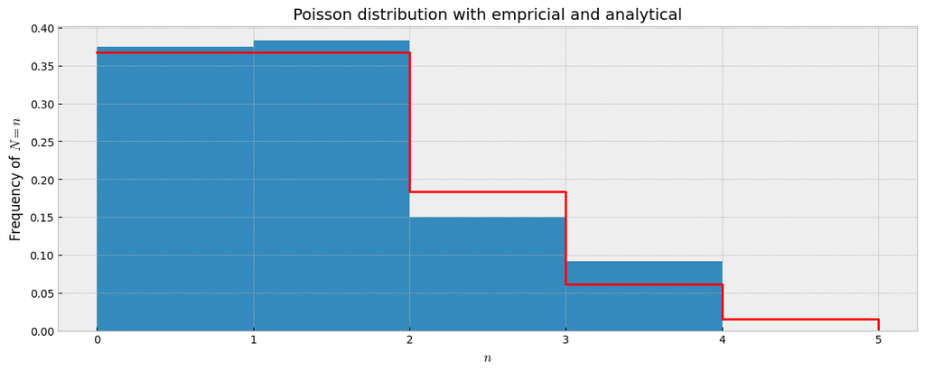

```python
# a) the arrival rate, 10 students per 10 minutes

mean = 1 #1 student per minute
trials = 120 #120min = 2 hours
sample_mean = np.random.poisson(mean, trials)

x = np.arange(0, ss.poisson.ppf(0.9999, mean))
analytical = ss.poisson.pmf(x, mean)
n_bins = np.max(sample_mean)

plt.figure(figsize = (14, 5))
plt.hist(sample_mean, n_bins, density=True)
plt.step(analytical, 'r', where='post')
plt.xlabel('$n$')
plt.ylabel('Frequency of $N = n$')
plt.title('Poisson distribution with empricial and analytical')
plt.show()
```

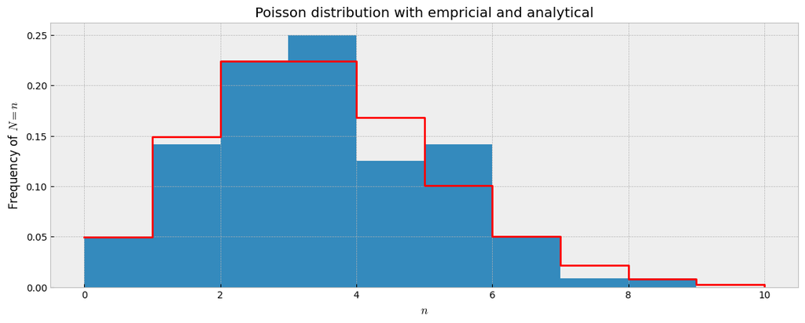

```python
#b) the arrival rate, 30 students per 10 minutes

mean = 3 #1 student per minute so it is 3
trials = 120 #120min = 2 hours
sample_mean = np.random.poisson(mean, trials)

x = np.arange(0, ss.poisson.ppf(0.9999, mean))
analytical = ss.poisson.pmf(x, mean)
n_bins = np.max(sample_mean)

plt.figure(figsize = (14, 5))
plt.hist(sample_mean, n_bins, density=True)
plt.step(analytical, 'r', where='post')
plt.xlabel('$n$')
plt.ylabel('Frequency of $N = n$')
plt.title('Poisson distribution with empricial and analytical')
plt.show()
```

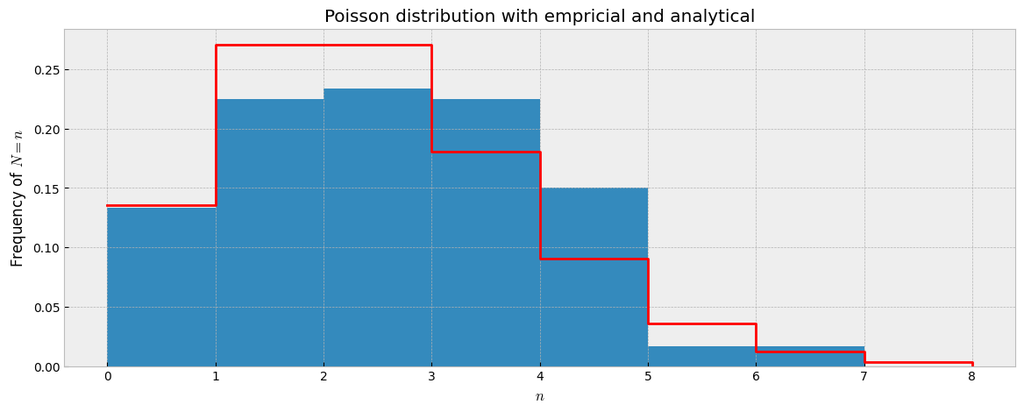

```python
#c) the arrival rate, 20 students per 10 minutes

mean = 2 #1 student per minute so it is 3
trials = 120 #120min = 2 hours
sample_mean = np.random.poisson(mean, trials)

x = np.arange(0, ss.poisson.ppf(0.9999, mean))
analytical = ss.poisson.pmf(x, mean)
n_bins = np.max(sample_mean)

plt.figure(figsize = (14, 5))
plt.hist(sample_mean, n_bins, density=True)
plt.step(analytical, 'r', where='post')
plt.xlabel('$n$')
plt.ylabel('Frequency of $N = n$')
plt.title('Poisson distribution with empricial and analytical')
plt.show()
```

**4. Using the code from the tutorial, simulate these three scenarios (one scenario per cell, do not combine the three scenarios in the same code). In this case, the restaurant put more works so the service rate varies as follows.**

**NOTE 1: Compute using rates in students per hour as input of the code.**

**NOTE 2: Simulation time is 2 hours.**

**NOTE 3: The analytical formulation only works when the queue is stable, i.e. arrival rates lower than service rates**

**(a) For two hours between 9 and 11, the arrival rate is 10 students per 10 minutes. Service rate is 10 students per 10 minutes.**

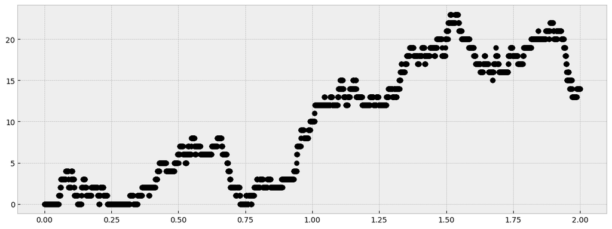

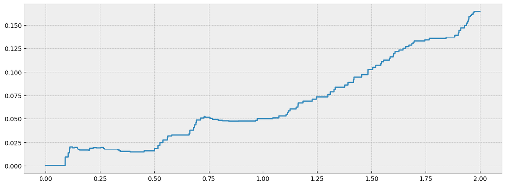

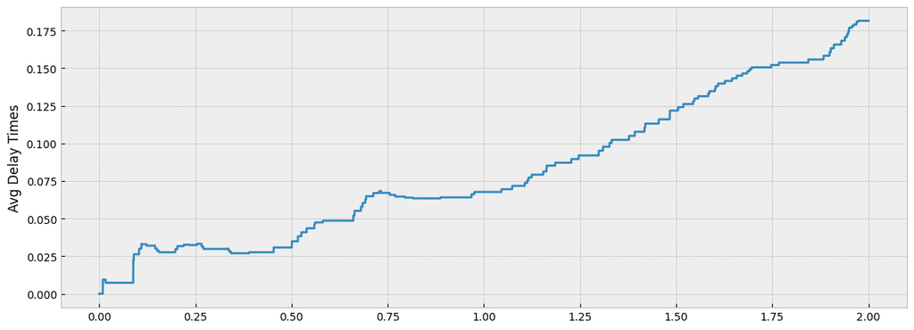

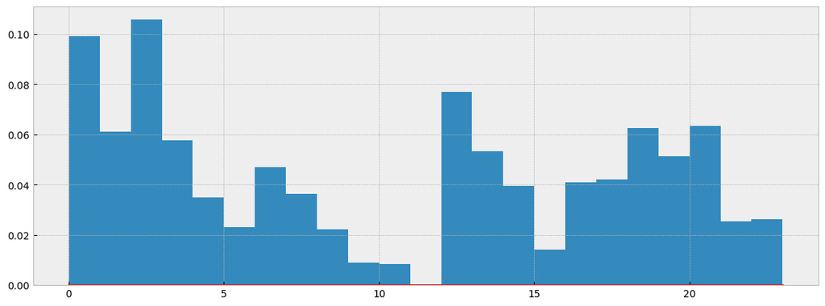

```
Idle ratio: 0.04236111111111111
Empty queue probability: 0.0
```

```python
import queue
import copy

total_time = 2 #hours
IAT_rate = 60 #60 students per hour
ST_rate = 60 #60 students per hour
rho = IAT_rate/ST_rate

#Initializing

qu = queue.Queue()
curr_process = None
IAT = []
ST = []
AT = []
wait_time = []
server_busy = False
list_wait = []
list_delay = []
num_processes_served = 0
total_time_seconds = total_time * 60 * 60

IAT.append(0)
i = 1

while np.sum(IAT) < total_time_seconds:
    i += 1
    temp = np.random.exponential(1/IAT_rate) * 60 * 60
    IAT.append(int(temp - temp%1))
num_processes = i

while not len(ST) == num_processes:
    temp = np.random.exponential(1/ST_rate) * 60 * 60
    if not int(temp-temp%1) < 1:
        ST.append(int(temp - temp%1))

ST_copy = copy.deepcopy(ST)

for i in range(num_processes):
    if i == 0:
        AT.append(0)
    else:
        AT.append(AT[i-1] + IAT[i])
    wait_time.append(0)

queue_size = np.zeros(total_time_seconds)
empty_system = 0



for i in range(total_time_seconds):
    queue_size[i] = qu.qsize()
    if server_busy:
        for item in list(qu.queue):
            wait_time[item] += 1
        ST[curr_process] -= 1
        if ST[curr_process] == 0:
            server_busy = False
            num_processes_served += 1


    for j in range(num_processes):
        if i == AT[j]:
            qu.put(j)

    if not server_busy and not qu.empty():
        curr_process = qu.get()
        server_busy = True

    if not server_busy and qu.empty():
        empty_system += 1

    sum_wait = 0
    sum_delay = 0

    for i in range(num_processes_served):
        sum_wait += wait_time[i]
        sum_delay += wait_time[i] + ST_copy[i]

    if num_processes_served == 0:
        list_wait.append(0)
        list_delay.append(0)
    else:
        list_wait.append(sum_wait/(num_processes_served * 60 * 60))
        list_delay.append(sum_delay/(num_processes_served * 60 * 60))

#Analytical


time_hours = np.linspace(0, total_time, total_time * 60 * 60)

plt.figure(figsize=(14, 5))
plt.plot(time_hours, queue_size, 'ok')

plt.figure(figsize=(14, 5))
plt.plot(time_hours, list_wait)
#plt.plot([0, total_time], [QWT, QWT])

plt.figure(figsize=(14,5))
plt.plot(time_hours, list_delay)
#plt.plot([0, total_time], [WT, WT])
plt.ylabel("Avg Delay Times")
plt.show()

plt.figure(figsize=(14,5))
n_bins = np.max(queue_size)
##
plt.hist(queue_size,n_bins.astype(int),density=True)
x = np.arange(0, n_bins+1)
p_analytical = (1-rho)*rho**x
p_analytical[1]= p_analytical[0] + p_analytical[1]
p_analytical[0]= 0
plt.step(p_analytical,'r')
plt.show()

print('Idle ratio:',empty_system/(total_time*60*60))
print('Empty queue probability:', 1 -  rho)
```

**(b) For two hours between 11 and 13, the arrival rate is 30 students per 10 minutes. Service rate is 35 students per 10 minutes.**

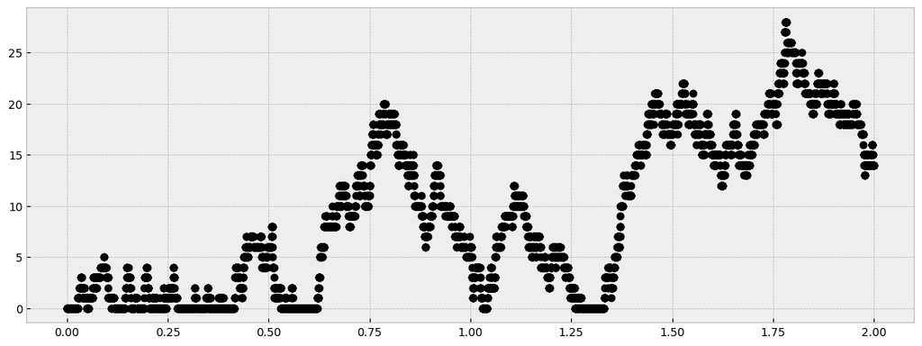

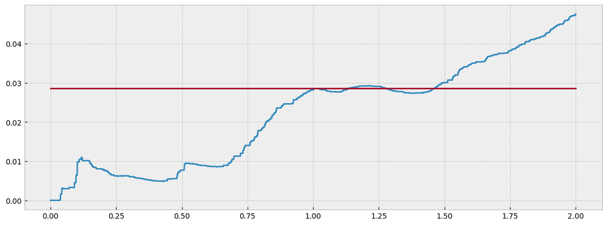

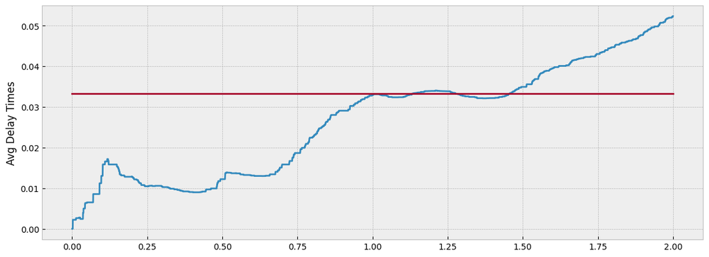

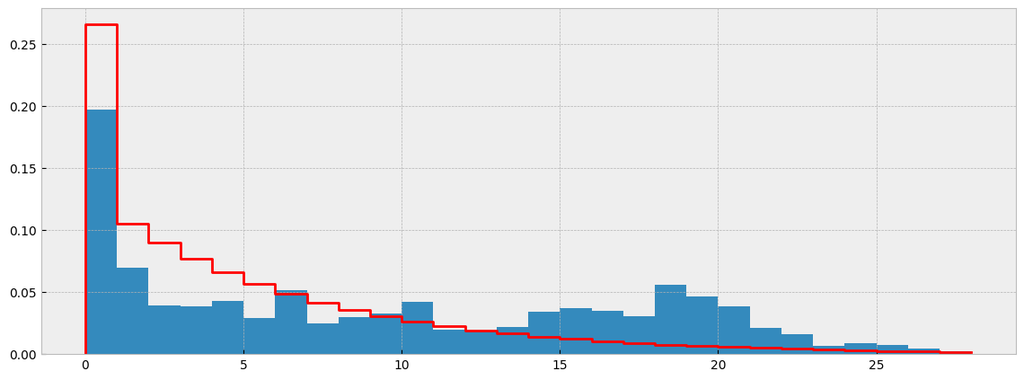

```
Idle ratio: 0.11347222222222222
Empty queue probability: 0.1428571428571429
Wait time in queue 0.028571428571428557
Delay time in system 0.03333333333333332
```

```python
# b)


total_time = 2 #hours
IAT_rate = 180 #180 students per hour
ST_rate = 210 #210 students per hour
rho = IAT_rate/ST_rate

#Initializing

qu = queue.Queue()
curr_process = None
IAT = []
ST = []
AT = []
wait_time = []
server_busy = False
list_wait = []
list_delay = []
num_processes_served = 0
IAT.append(0)
i = 1

while np.sum(IAT) < total_time_seconds:
    i += 1
    temp = np.random.exponential(1/IAT_rate) * 60 * 60
    IAT.append(int(temp - temp%1))
num_processes = i

while not len(ST) == num_processes:
    temp = np.random.exponential(1/ST_rate) * 60 * 60
    if not int(temp-temp%1) < 1:
        ST.append(int(temp - temp%1))

ST_copy = copy.deepcopy(ST)

for i in range(num_processes):
    if i == 0:
        AT.append(0)
    else:
        AT.append(AT[i-1] + IAT[i])
    wait_time.append(0)

queue_size = np.zeros(total_time_seconds)
empty_system = 0
#num_processed_server_seconds = num_processes_served * 60 * 60


for i in range(total_time_seconds):
    queue_size[i] = qu.qsize()
    if server_busy:
        for item in list(qu.queue):
            wait_time[item] += 1
        ST[curr_process] -= 1
        if ST[curr_process] == 0:
            server_busy = False
            num_processes_served += 1


    for j in range(num_processes):
        if i == AT[j]:
            qu.put(j)

    if not server_busy and not qu.empty():
        curr_process = qu.get()
        server_busy = True

    if not server_busy and qu.empty():
        empty_system += 1

    sum_wait = 0
    sum_delay = 0

    for i in range(num_processes_served):
        sum_wait += wait_time[i]
        sum_delay += wait_time[i] + ST_copy[i]

    if num_processes_served == 0:
        list_wait.append(0)
        list_delay.append(0)
    else:
        list_wait.append(sum_wait/(num_processes_served * 60 * 60))
        list_delay.append(sum_delay/(num_processes_served * 60 * 60))

###Analytical
QWT = 1/((1-rho)*ST_rate) - 1/ST_rate
WT = 1/((1-rho)*ST_rate)


time_hours = np.linspace(0, total_time, total_time_seconds)

plt.figure(figsize=(14, 5))
plt.plot(time_hours, queue_size, 'ok')

plt.figure(figsize=(14, 5))
plt.plot(time_hours, list_wait)
plt.plot([0, total_time], [QWT, QWT])

plt.figure(figsize=(14,5))
plt.plot(time_hours, list_delay)
plt.plot([0, total_time], [WT, WT])
plt.ylabel("Avg Delay Times")
plt.show()

plt.figure(figsize=(14,5))
n_bins = np.max(queue_size)
##
plt.hist(queue_size,n_bins.astype(int),density=True)
x = np.arange(0, n_bins+1)
p_analytical = (1-rho)*rho**x
p_analytical[1]= p_analytical[0] + p_analytical[1]
p_analytical[0]= 0
plt.step(p_analytical,'r')
plt.show()

print('Idle ratio:',empty_system/(total_time*60*60))
print('Empty queue probability:', 1 -  rho)
print('Wait time in queue',QWT)
print('Delay time in system',WT)
```

(c) For two hours between 13 and 15, the arrival rate is 20 students per 10 minutes. Serice rate is 19 students per 10 minutes.

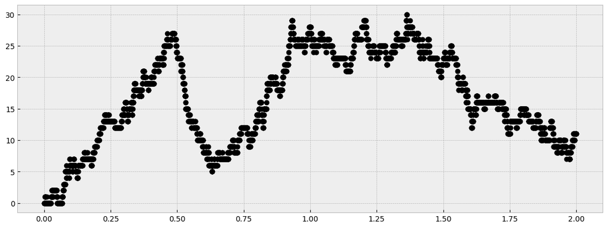

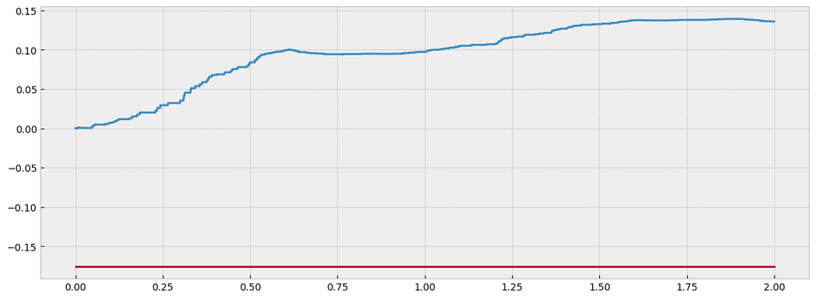

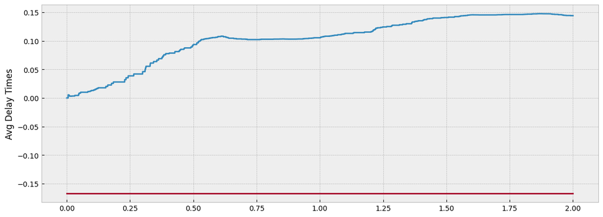

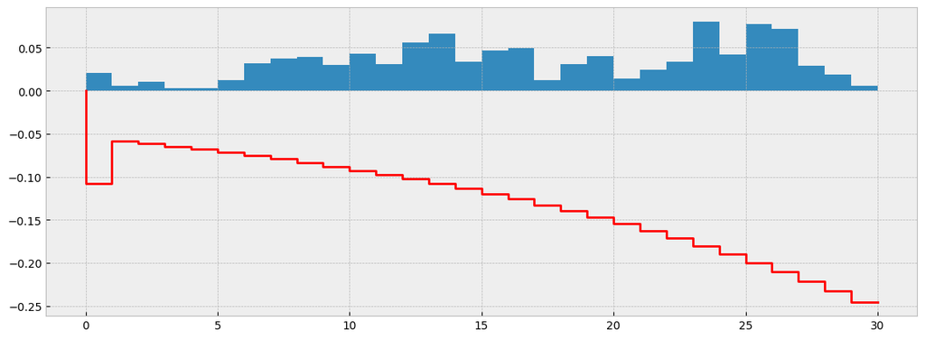

```
Idle ratio: 0.009027777777777777
Empty queue probability: -0.05263157894736836
Wait time in queue -0.17543859649122825
Delay time in system -0.16666666666666685
```

```python
# b)


total_time = 2 #hours
IAT_rate = 120 #180 students per hour
ST_rate = 114 #210 students per hour
rho = IAT_rate/ST_rate

#Initializing

qu = queue.Queue()
curr_process = None
IAT = []
ST = []
AT = []
wait_time = []
server_busy = False
list_wait = []
list_delay = []
num_processes_served = 0
IAT.append(0)
i = 1

while np.sum(IAT) < total_time_seconds:
    i += 1
    temp = np.random.exponential(1/IAT_rate) * 60 * 60
    IAT.append(int(temp - temp%1))
num_processes = i

while not len(ST) == num_processes:
    temp = np.random.exponential(1/ST_rate) * 60 * 60
    if not int(temp-temp%1) < 1:
        ST.append(int(temp - temp%1))

ST_copy = copy.deepcopy(ST)

for i in range(num_processes):
    if i == 0:
        AT.append(0)
    else:
        AT.append(AT[i-1] + IAT[i])
    wait_time.append(0)

queue_size = np.zeros(total_time_seconds)
empty_system = 0
#num_processed_server_seconds = num_processes_served * 60 * 60


for i in range(total_time_seconds):
    queue_size[i] = qu.qsize()
    if server_busy:
        for item in list(qu.queue):
            wait_time[item] += 1
        ST[curr_process] -= 1
        if ST[curr_process] == 0:
            server_busy = False
            num_processes_served += 1


    for j in range(num_processes):
        if i == AT[j]:
            qu.put(j)

    if not server_busy and not qu.empty():
        curr_process = qu.get()
        server_busy = True

    if not server_busy and qu.empty():
        empty_system += 1

    sum_wait = 0
    sum_delay = 0

    for i in range(num_processes_served):
        sum_wait += wait_time[i]
        sum_delay += wait_time[i] + ST_copy[i]

    if num_processes_served == 0:
        list_wait.append(0)
        list_delay.append(0)
    else:
        list_wait.append(sum_wait/(num_processes_served * 60 * 60))
        list_delay.append(sum_delay/(num_processes_served * 60 * 60))

###Analytical
QWT = 1/((1-rho)*ST_rate) - 1/ST_rate
WT = 1/((1-rho)*ST_rate)


time_hours = np.linspace(0, total_time, total_time_seconds)

plt.figure(figsize=(14, 5))
plt.plot(time_hours, queue_size, 'ok')

plt.figure(figsize=(14, 5))
plt.plot(time_hours, list_wait)
plt.plot([0, total_time], [QWT, QWT])

plt.figure(figsize=(14,5))
plt.plot(time_hours, list_delay)
plt.plot([0, total_time], [WT, WT])
plt.ylabel("Avg Delay Times")
plt.show()

plt.figure(figsize=(14,5))
n_bins = np.max(queue_size)
##
plt.hist(queue_size,n_bins.astype(int),density=True)
x = np.arange(0, n_bins+1)
p_analytical = (1-rho)*rho**x
p_analytical[1]= p_analytical[0] + p_analytical[1]
p_analytical[0]= 0
plt.step(p_analytical,'r')
plt.show()

print('Idle ratio:',empty_system/(total_time*60*60))
print('Empty queue probability:', 1 -  rho)
print('Wait time in queue',QWT)
print('Delay time in system',WT)
```

**5. Discussions about the results.**

- What is the impact of a simulation time of 2 hours?

The impact of a simulation time of 2 hours has the practical implication of making the simulation run in a reasonable amount of time on a regular computer. I noticed that the program has many nested loops which impacts performance.

- In the simulations, the 3 periods were also considered independent, i.e. the initial states of the queues were always considered 0. What is the impact of this assumption? (No need to simulate, just arguments)

This affects the simulation because if the service rate is equal to or less than the arrival rate, the queue will not be empty when the next period arrives. This means that the next period cannot be served until the previous queue is empty, causing significant delays in the case of a service rate lower than the arrival rate.

- Would be this a sound model? Why?

**Challenge (not to be graded). Simulate a more realistic queue system considering that the three periods are sequencial and that the last period only ends after the last service is complete. When the restaurant is closed?**